# Challenge

In today's reading, your challenge is to return to our "toy" power grid system, and try to understand, given non-negiglible power line resistance, how much voltage will be available to your cabin at any given time. In general, our goal is to see whether the first law of thermodynamics offers us a "shortcut" to relating the *voltages* in this system to one another, the way it offered us an easy way to relate the *currents* in our system when we introduced the concept of a node.

We will consider the small, cabin-in-the-woods DC (direct current) power grid (including a storage system) given by the following schematic. You've set up this system to power small electronics in your cabin, because you didn't feel that a large, AC power system was necessary.

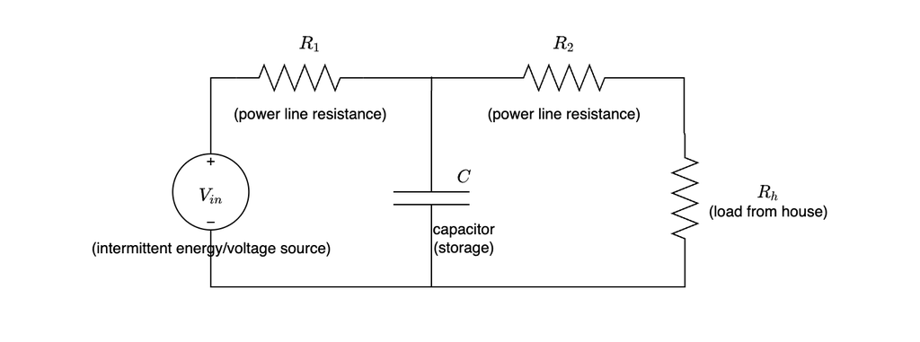

As before, the voltage source could be an intermittent power generation station like a [wind turbine](https://www.amazon.com/Happybuy-Generator-Starting-Bearings-Controller/dp/B07D763M7S) or solar farm. This source is connected to power lines with resistance $R_1$, and then to a storage bank, which we will model as an ideal capacitor (This may not be a very good model of a *real* storage bank, which likely consists instead of batteries that don't behave quite like capacitors). From the storage, bank, the power runs to your cabin through more power lines with an effective resistance $R_2$. The electrical load in your cabin can be modeled by an approximately constant resistance $R_h$.

## Challenge: System Scoping

In scoping your model of this system, you choose to represent the intermittent renewable energy source as an external input. Given your newfound knowledge about "nodes," which represent idealized points between elements where power is transmitted "perfectly," making the first law of thermodynamics for a node reduce to $\dot{W}_{in} = \dot{W}_{out}$, you annotate the circuit diagram to mark the distinct voltages in the schematic like so:

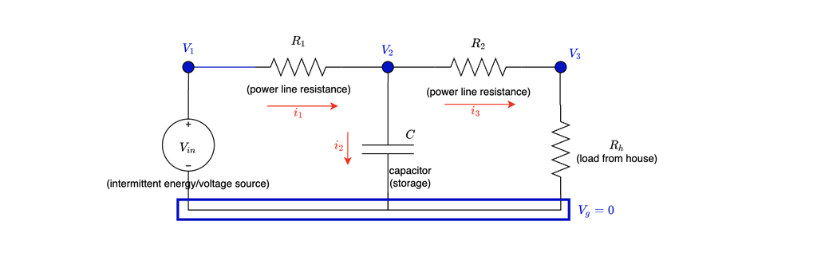

Then, you make a list of independent and dependent variables (yes, this is often done as part of model construction, but there's no reason we can't do it now!). Because you're interested in the voltage at the house, your list reads:

**independent**

- $R_1$
- $R_2$
- $R_h$
- $C$

**Dependent**

- $V_3,\dot{V}_3$

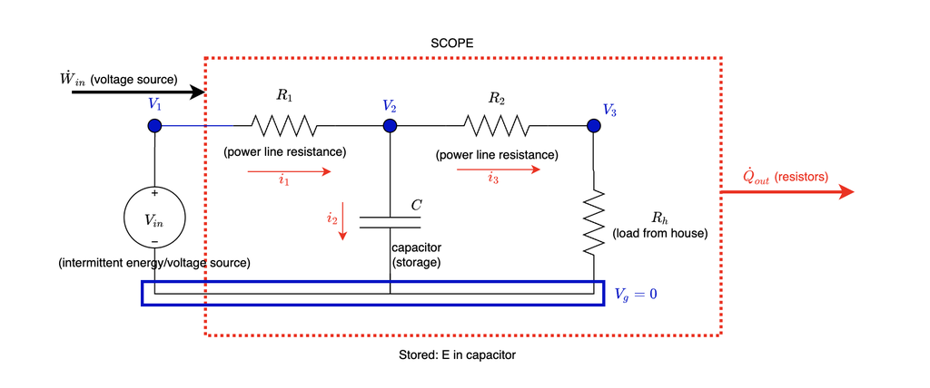

Representing this as an energetic diagram, you find the following simplified form of the time-derivative of the first law:

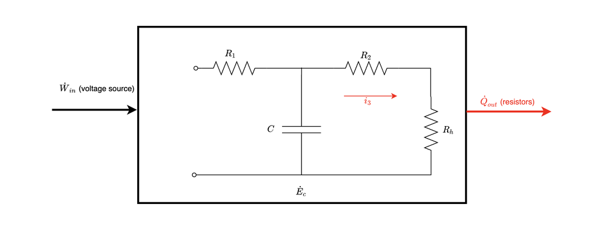

Which can be written as the following equation: $$\require{cancel}$$ $$\dot{E} = \dot{W}_{in} - \dot{Q}_{out}$$

The input work $\dot{W}_{in}$ is expected to come from the voltage source. While you don't expect any heat added to the system to increase its stored energy, you know that the resistors will transfer heat to the environment. you also know that because of the capacitor in the system, we know that the system will accumulate energy over time if $\dot{W}_{in}>0$. Now, as usual, you write the first law for each of the components in your system, with the appropriate assumptions for each "idealized" component:

**R1**

$$\dot{W}_{in} - \dot{W}_{out} = V_1i_1 - V_2i_1 = i_1^2 R_1$$$$\therefore V_{1}-V_{2} = i_1R_1$$

**R2**

$$\dot{W}_{in} - \dot{W}_{out} = V_2i_3 - V_3i_3 = i_3^2 R_2$$$$\therefore V_{2} - {V}_3 = i_3R_2$$

**Rh**

$$\dot{W}_{in} - \dot{W}_{out} = V_3i_3 - \cancel{V_g}i_3 = i_3^2 R_h$$$$\therefore V_{3} - \cancel{V}_g = i_3R_h$$

**C**

$$\dot{W}_{in} - \dot{W}_{out} = V_2i_2 - \cancel{V_g}i_3 = CV_2 \dot{V}_2$$$$\therefore i_2 = C\dot{V}_2$$

You also know that because of the *node* 2 that causes a split in current, you can write an equation for the "node" where voltage is equal to $V_2$ using KCL, which we derived using the first law in Reading 13.

$$i_1 = i_2+i_3$$

This collection of representations of the first law of thermodynamics for the elements in your system allows you to re-write the first law for the entire system, taking all of the individual components' contributions into account. Because we are looking for a relationship between the *voltages* in our system, we will leave all of the equations in the form that exposes the voltages $V_1,V_2,V_3$.

We know that the heat transfer out of the system is simply the balance of work into each resistor:

$$\dot{Q}_{out,system} = (V_1 - V_2) i_1 + (V_2 - V_3)i_3 + (V_3)i_3$$

We also know that the energy stored inside the system is due to energy stored in the capacitor. Using the first law equation for the capacitor, we can see that:

$$\dot{E}_{system} = \dot{E}_{cap} = V_2 i_2$$

Finally, we know that the work into the system comes from the voltage source.

$$\dot{W}_{in,system} = V_1 i_1$$

This means that **the entire system's** first law equation:

$$\dot{E} = \dot{W}_{in} - \dot{Q}_{out}$$

Can be re-written as:

$$V_2 i_2 = V_1 i_1 - ((V_1 - V_2) i_1 + (V_2 - V_3)i_3 + (V_3)i_3)$$

Using the node 2 equation, we can replace $i_2 = i_1 - i_3$ to get:

$$V_2 (i_1 - i_3) = V_1 i_1 - ((V_1 - V_2) i_1 + (V_2 - V_3)i_3 + (V_3)i_3)$$

Expanding this, rearranging it, and solving for the voltage $V_1$, we find that a curious identity emerges:

$$V_1 = (V_1 - V_2) + (V_2 - V_3) + (V_3)$$

This, as with many forms of the first law, doesn't tell us everything we need to know, but if we define:

$$V_1 - V_2 \equiv V_{12}$$

as the "voltage drop across resistor $R_1$," and we define:

$$V_2 - V_3 \equiv V_{23}$$

as the "voltage drop across resistor $R_2$," and:

$$V_3 - \cancel{V}_g = V_{3g} = V_3$$

as the "voltage drop across $R_h$, we can re-write this equation as:

$$V_1 = V_{12} + V_{23} + V_{3g}$$

This is what engineers call "the principle of compatibility," also known as "Kirchoff's Voltage Law" for electrical systems. We know that it is just a statement of the first law of thermodynamics, but it can actually be derived for any subsystem you could think of comprised of our system's components. If we "cut off" our system boundary to only include $C$, $R_2$, and $R_3$, with an input of $V_2i_2$, we could perform a similar analysis. The same is true if we were to "cut off" our system boundary to only include $R_1$ and $C$, with an input power of $V_1 i_1$ and an output power of $V_2 i_3$, we could do yet another similar analysis.

**But this would take a long time!** This is why system dynamicists use "Kirchoff's Voltage Law" to speed up the process.

Commonly, Kirchoff's Voltage Law is written:

"The sum of the voltage *drops* across the elements in any "closed loop" in a circuit must be zero.

Because in our system $V_1i_1 = \dot{W}_{in}$ represents a voltage *gain* (a negative voltage drop across the source), this is equivalent to what we've derived.